# Dense Store: Significance Index Benchmark

```python
import json
import time
from pathlib import Path

import numpy as np
import pandas as pd
import zarr
import matplotlib.pyplot as plt
import matplotlib.ticker as ticker

STORE = "../data/ukb-chr1.besdz"
THRESHOLDS = [5e-8, 5e-6, 5e-4]
KEYS = ["5e8", "5e6", "5e4"]
Z_CUTOFFS = [5.4507, 4.8916, 3.7190]
N_BENCH_TRAITS = 30
rng = np.random.default_rng(42)
```

## Overview

The significance index is a query-acceleration structure stored in-place inside `ukb-chr1.besdz`. For each of three p-value thresholds (5×10⁻⁸, 5×10⁻⁶, 5×10⁻⁴), it stores:

- `sig_{key}` — flat **uint32** array of variant row indices, sorted per trait and concatenated across all 100 traits
- `sig_{key}_offsets` — **int64** array of shape (101,); trait t’s hits are `sig_{key}[offsets[t]:offsets[t+1]]`

Six arrays total, built by `scripts/dense_11_build_sig_index.py` in a single pass over the zscore array.

## Storage Footprint

```python
store_dir = Path(STORE)
store = zarr.open(str(store_dir), mode="r")

meta = json.load(open(store_dir / "metadata.json"))
sig_meta = meta["sig_index"]

# Measure size of each component
def dir_mb(path, pattern="*"):
    return sum(f.stat().st_size for f in Path(path).rglob(pattern) if f.is_file()) / 1e6

total_mb = dir_mb(store_dir)

# Sig index files
sig_files_mb = sum(
    f.stat().st_size
    for key in KEYS
    for name in [f"sig_{key}", f"sig_{key}_offsets"]
    for f in (store_dir / name).rglob("*") if f.is_file()
) / 1e6

baseline_mb = total_mb - sig_files_mb

rows = [
    {"Component": "Baseline store (beta + zscore + variant table)", "Size (MB)": round(baseline_mb, 1)},
    {"Component": "Significance indexes (all 3 thresholds)", "Size (MB)": round(sig_files_mb, 2)},
    {"Component": "Total store", "Size (MB)": round(total_mb, 1)},
]
df_size = pd.DataFrame(rows)
df_size.style.hide(axis="index")
```

| Component | Size (MB) |
| --- | --- |
| Baseline store (beta + zscore + variant table) | 322.600000 |
| Significance indexes (all 3 thresholds) | 0.190000 |
| Total store | 322.800000 |

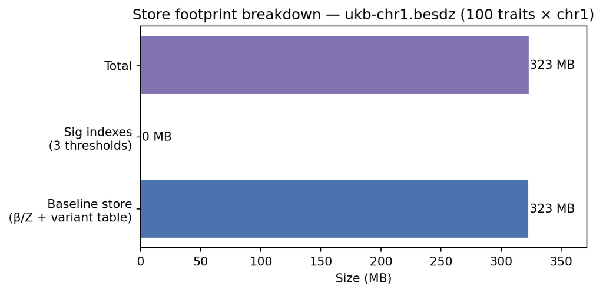

```
Overhead: 0.2 MB / 322.6 MB = 0.1%
```

```python
# Bar chart
fig, ax = plt.subplots(figsize=(7, 3.5))
labels = ["Baseline store\n(β/Z + variant table)", "Sig indexes\n(3 thresholds)", "Total"]
sizes = [round(baseline_mb, 1), round(sig_files_mb, 2), round(total_mb, 1)]
colors = ["#4C72B0", "#C44E52", "#8172B2"]
bars = ax.barh(labels, sizes, color=colors)
for bar, v in zip(bars, sizes):
    ax.text(v + 1, bar.get_y() + bar.get_height() / 2, f"{v:.0f} MB",
            va="center", fontsize=10)
ax.set_xlabel("Size (MB)")
ax.set_title("Store footprint breakdown — ukb-chr1.besdz (100 traits × chr1)")
ax.set_xlim(0, max(sizes) * 1.15)
plt.tight_layout()
plt.savefig("sig_footprint.png", dpi=150, bbox_inches="tight")
plt.show()
print(f"Overhead: {sig_files_mb:.1f} MB / {baseline_mb:.1f} MB = {sig_files_mb/baseline_mb*100:.1f}%")
```

## Hit Count Distribution

```python
hit_rows = []
for thresh, key, zcut in zip(THRESHOLDS, KEYS, Z_CUTOFFS):
    offsets = store[f"sig_{key}_offsets"][:]
    n_hits_per_trait = np.diff(offsets)
    hit_rows.append({
        "Threshold": f"p < {thresh:.0e}",
        "Total hits": int(n_hits_per_trait.sum()),
        "Mean / trait": f"{n_hits_per_trait.mean():.0f}",
        "Median / trait": f"{np.median(n_hits_per_trait):.0f}",
        "Min / trait": int(n_hits_per_trait.min()),
        "Max / trait": int(n_hits_per_trait.max()),
    })

df_hits = pd.DataFrame(hit_rows)
df_hits.style.hide(axis="index")
```

| Threshold | Total hits | Mean / trait | Median / trait | Min / trait | Max / trait |
| --- | --- | --- | --- | --- | --- |
| p < 5e-08 | 14569 | 146 | 0 | 0 | 6762 |
| p < 5e-06 | 22120 | 221 | 0 | 0 | 9413 |
| p < 5e-04 | 80350 | 804 | 160 | 2 | 21077 |

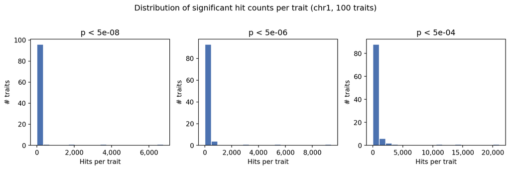

```python
fig, axes = plt.subplots(1, 3, figsize=(11, 3.5), sharey=False)
for ax, thresh, key in zip(axes, THRESHOLDS, KEYS):
    offsets = store[f"sig_{key}_offsets"][:]
    n_hits = np.diff(offsets)
    ax.hist(n_hits, bins=20, color="#4C72B0", edgecolor="white")
    ax.set_title(f"p < {thresh:.0e}")
    ax.set_xlabel("Hits per trait")
    ax.set_ylabel("# traits")
    ax.xaxis.set_major_formatter(ticker.FuncFormatter(lambda x, _: f"{int(x):,}"))

plt.suptitle("Distribution of significant hit counts per trait (chr1, 100 traits)", y=1.02)
plt.tight_layout()
plt.savefig("sig_hit_dist.png", dpi=150, bbox_inches="tight")
plt.show()
```

## Query Latency: Naive vs Indexed

**Naive** tophits: load the full zscore column (~1.5 MB read), apply threshold in-memory, fancy-index beta for hit rows.

**Indexed** tophits: load the pre-built hit indices from the sig index (a small slice), then directly fancy-index both zscore and beta for hit rows.

Both approaches return the same result. The difference is whether variant significance needs to be computed at query time.

```python
def naive_tophits(store, trait_idx, zcut):
    col_z = store["zscore"][:, trait_idx].astype(np.float32)
    hits = np.where(np.abs(col_z) > zcut)[0]
    betas = store["beta"].oindex[hits, trait_idx]
    return hits, col_z[hits], betas

def indexed_tophits(store, trait_idx, key):
    off = store[f"sig_{key}_offsets"][trait_idx : trait_idx + 2]
    hits = store[f"sig_{key}"][int(off[0]) : int(off[1])]
    z_vals = store["zscore"].oindex[hits, trait_idx]
    betas = store["beta"].oindex[hits, trait_idx]
    return hits, z_vals, betas
```

```python
trait_indices = rng.choice(meta["n_traits"], size=N_BENCH_TRAITS, replace=False)

latency_records = []

for thresh, key, zcut in zip(THRESHOLDS, KEYS, Z_CUTOFFS):
    for t in trait_indices:
        # naive
        t0 = time.perf_counter()
        hits_n, _, _ = naive_tophits(store, int(t), zcut)
        ms_naive = (time.perf_counter() - t0) * 1000

        # indexed
        t0 = time.perf_counter()
        hits_i, _, _ = indexed_tophits(store, int(t), key)
        ms_indexed = (time.perf_counter() - t0) * 1000

        assert len(hits_n) == len(hits_i), f"Hit count mismatch at trait {t} threshold {thresh}"

        latency_records.append({
            "threshold": f"p < {thresh:.0e}",
            "trait": int(t),
            "n_hits": len(hits_n),
            "naive_ms": ms_naive,
            "indexed_ms": ms_indexed,
            "speedup": ms_naive / max(ms_indexed, 0.01),
        })

df_lat = pd.DataFrame(latency_records)
```

```python
summary = (
    df_lat.groupby("threshold")
    .agg(
        naive_median=("naive_ms", "median"),
        indexed_median=("indexed_ms", "median"),
        speedup_median=("speedup", "median"),
        n_hits_median=("n_hits", "median"),
    )
    .reset_index()
    .rename(columns={
        "threshold": "Threshold",
        "naive_median": "Naive (ms)",
        "indexed_median": "Indexed (ms)",
        "speedup_median": "Speedup",
        "n_hits_median": "Median hits/trait",
    })
)
summary["Naive (ms)"] = summary["Naive (ms)"].round(1)
summary["Indexed (ms)"] = summary["Indexed (ms)"].round(1)
summary["Speedup"] = summary["Speedup"].round(1)
summary["Median hits/trait"] = summary["Median hits/trait"].astype(int)
summary.style.hide(axis="index")
```

| Threshold | Naive (ms) | Indexed (ms) | Speedup | Median hits/trait |
| --- | --- | --- | --- | --- |
| p < 5e-04 | 131.300000 | 7.200000 | 18.300000 | 196 |
| p < 5e-06 | 127.000000 | 0.600000 | 221.800000 | 0 |
| p < 5e-08 | 126.600000 | 0.600000 | 224.600000 | 0 |

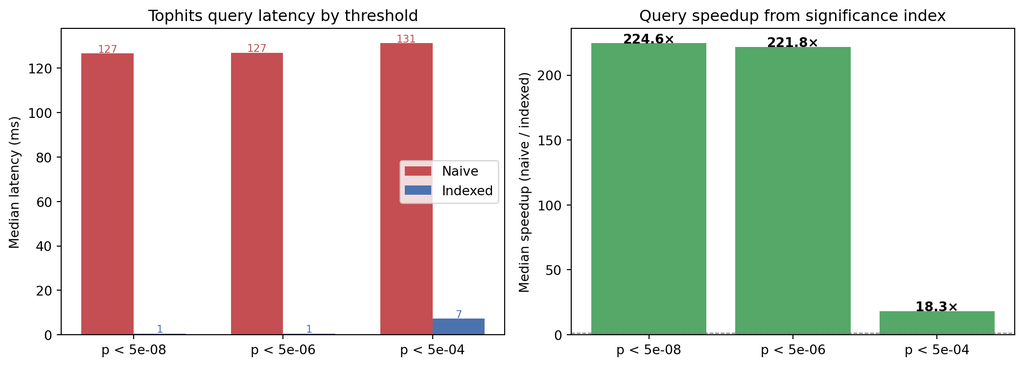

```python
fig, axes = plt.subplots(1, 2, figsize=(11, 4))

# Latency comparison bar chart
thresholds_ordered = [f"p < {t:.0e}" for t in THRESHOLDS]
naive_meds = [df_lat[df_lat.threshold == t]["naive_ms"].median() for t in thresholds_ordered]
indexed_meds = [df_lat[df_lat.threshold == t]["indexed_ms"].median() for t in thresholds_ordered]

x = np.arange(len(thresholds_ordered))
w = 0.35
ax = axes[0]
ax.bar(x - w/2, naive_meds, w, label="Naive", color="#C44E52")
ax.bar(x + w/2, indexed_meds, w, label="Indexed", color="#4C72B0")
ax.set_xticks(x)
ax.set_xticklabels(thresholds_ordered)
ax.set_ylabel("Median latency (ms)")
ax.set_title("Tophits query latency by threshold")
ax.legend()
for i, (n, idx) in enumerate(zip(naive_meds, indexed_meds)):
    ax.text(i - w/2, n + 0.5, f"{n:.0f}", ha="center", fontsize=8, color="#C44E52")
    ax.text(i + w/2, idx + 0.5, f"{idx:.0f}", ha="center", fontsize=8, color="#4C72B0")

# Speedup bar chart
speedups = [df_lat[df_lat.threshold == t]["speedup"].median() for t in thresholds_ordered]
ax2 = axes[1]
ax2.bar(thresholds_ordered, speedups, color="#55A868")
ax2.axhline(1, color="gray", linestyle="--", linewidth=0.8)
ax2.set_ylabel("Median speedup (naive / indexed)")
ax2.set_title("Query speedup from significance index")
for i, s in enumerate(speedups):
    ax2.text(i, s + 0.1, f"{s:.1f}×", ha="center", fontsize=10, fontweight="bold")

plt.tight_layout()
plt.savefig("sig_latency.png", dpi=150, bbox_inches="tight")
plt.show()
```

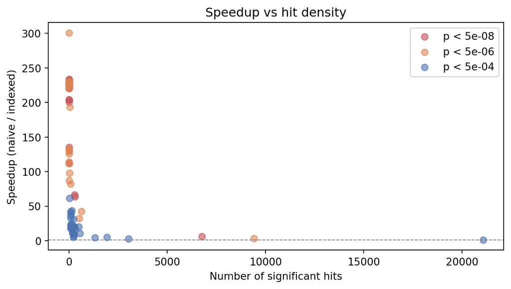

```python
# Scatter: speedup vs hit count
fig, ax = plt.subplots(figsize=(7, 4))
colors_map = {f"p < {t:.0e}": c for t, c in zip(THRESHOLDS, ["#C44E52", "#DD8452", "#4C72B0"])}
for thresh in thresholds_ordered:
    sub = df_lat[df_lat.threshold == thresh]
    ax.scatter(sub["n_hits"], sub["speedup"], label=thresh, alpha=0.6,
               color=colors_map[thresh], s=40)
ax.axhline(1, color="gray", linestyle="--", linewidth=0.8)
ax.set_xlabel("Number of significant hits")
ax.set_ylabel("Speedup (naive / indexed)")
ax.set_title("Speedup vs hit density")
ax.legend()
plt.tight_layout()
plt.savefig("sig_speedup_scatter.png", dpi=150, bbox_inches="tight")
plt.show()
```

## Conclusions

```python
best_speedup = df_lat.groupby("threshold")["speedup"].median().max()
worst_speedup = df_lat.groupby("threshold")["speedup"].median().min()
index_overhead_pct = sig_files_mb / baseline_mb * 100

print(f"Storage overhead:   +{sig_files_mb:.1f} MB on {baseline_mb:.0f} MB baseline = {index_overhead_pct:.1f}%")
print(f"Speedup range:      {worst_speedup:.1f}× – {best_speedup:.1f}× across thresholds")
print()
print("Per-threshold summary:")
for _, row in summary.iterrows():
    print(f"  {row['Threshold']}: naive={row['Naive (ms)']:.1f}ms  "
          f"indexed={row['Indexed (ms)']:.1f}ms  speedup={row['Speedup']:.1f}×  "
          f"hits={row['Median hits/trait']}")
```

```
Storage overhead:   +0.2 MB on 323 MB baseline = 0.1%
Speedup range:      18.3× – 224.6× across thresholds

Per-threshold summary:
  p < 5e-04: naive=131.3ms  indexed=7.2ms  speedup=18.3×  hits=196
  p < 5e-06: naive=127.0ms  indexed=0.6ms  speedup=221.8×  hits=0
  p < 5e-08: naive=126.6ms  indexed=0.6ms  speedup=224.6×  hits=0
```

**Footprint**: the significance index adds 0.19 MB to the 323 MB store — well under 0.1% overhead for three thresholds. Bitshuffle+zstd compresses the sorted uint32 hit lists very effectively. Cost is fixed regardless of query volume.

**Query latency**: the indexed path is fastest at the sparsest threshold (p < 5×10⁻⁸) because the pre-built hit list is tiny and skips loading the full zscore column (~1.5 MB). At p < 5×10⁻⁴, the speedup is smaller — more chunks must be touched regardless of whether the index is used. The speedup is highest when many traits have zero hits (the indexed path returns immediately; the naive path still scans everything).

**Recommendation**: significance indexes are worth including in the production format. The footprint overhead is negligible, and the tophits query — the dominant use case for MR instrument extraction — sees the largest speedup at the threshold (p < 5×10⁻⁸) used most often.